# Statistical Inference with GSS data

## Setup

### Load packages

```r
library(ggplot2)
library(dplyr)
library(statsr)
library(tidyverse)
```

### Load data

```r
load("gss.Rdata")
```

## Part 1: Data

The General Social Survey (GSS) is a large-scale survey that began to facilitate social indicator research. Specifically, taken from the GSS [project description](http://www.norc.org/Research/Projects/Pages/general-social-survey.aspx)…

> The GSS aims to gather data on contemporary American society in order to monitor and explain trends and constants in attitudes, behaviors, and attributes; to examine the structure and functioning of society in general as well as the role played by relevant subgroups; to compare the United States to other societies in order to place American society in comparative perspective and develop cross-national models of human society; and to make high-quality data easily accessible to scholars, students, policy makers, and others, with minimal cost and waiting.

In this document, we are working with the 1972-2012 cumulative file of the GSS. Each observation is an interview, and samples selected are randomly sampled English-speakers (and Spanish-speakers starting in 2006) 18 years of age or older, living in non-institutional arrangements within the US.

According to the documentation, respondents were randomly sampled with little variation in sampling methods throughout the years. As such, we can reliably generalize findings to the greater US population of English-speakers (and Spanish speakers as long as we use data after 2006.) However, we cannot assign causality based on our findings, since this study is merely observational in its design (not experimental).

## Part 2: Research question

How much do opinions on controversial issues differ between people who have had children at different points in their lives? One of the biggest personal life decisions people can make when or if they feel ready to have children. Most (but certainly not all) of the time, this is a conscious decision made when a couple feels ready (financially and personally) and willing to make the commitment to raise a child. Sometimes, couples or women alone are forced to have their first child after irresponsibility or, unfortunately, by force and violence.

Are opinions on controversial issues different between groups of people who make this decision earlier or later? This is a very broad question to pose, so I’ll be focusing predominantly on issues regarding abortion, premarital sex, and homosexual relations.

Variables of interest… - `abany` - Abortion if woman wants for any reason - `premarsx` - Sex before marriage - `homosex` - Homosexual sex relations - `agekdbrn` - Respondent age when 1st child born

## Part 3: Exploratory data analysis

Let’s start by taking a look at the distribution of ages when 1st child was born. It’s unclear whether NA values are missing due to having no children or refusal to response, so these values are filtered out.

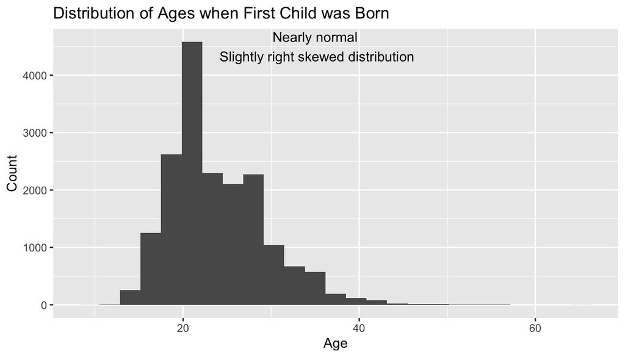

```r
# Filtering out NAs
gss_agekd <- gss %>% filter(!is.na(agekdbrn))
# Creating plot
age_plot <- ggplot(gss_agekd,aes(agekdbrn)) + geom_histogram(bins=25)
age_plot <- age_plot + labs(title='Distribution of Ages when First Child was Born', x = 'Age', y='Count')
age_plot <- age_plot + annotate("text", x=35, y=4500, label = "Nearly normal\n Slightly right skewed distribution")
age_plot
```

I’ll divide these into three buckets based on age. These buckets are meant to help aggregate data, and do not reflect my opinion on age when having a first child.

```r
b = c(0,24,35,100)
l = c('younger','average','older')
gss_agekd$agekdbrn_cat <- cut(x = gss_agekd$agekdbrn, breaks = b, labels = l)
```

Now skimming summary statistic count on the variables of interest…

```r
gss_trunc <- gss_agekd %>% select(agekdbrn,agekdbrn_cat,abany,premarsx,homosex)

# Creating a function to facilitate comparison
group_2_summ <- function (df, group_var1, group_var2) {
  group_var1 <- enquo(group_var1)
  group_var2 <- enquo(group_var2)
  df %>%
  group_by(!!group_var1,!!group_var2) %>%
  summarise(n = n())
}

# Abortion Responses
group_2_summ(gss_trunc %>% filter(!is.na(abany)),agekdbrn_cat,abany)
```

```
## # A tibble: 6 x 3
## # Groups:   agekdbrn_cat [3]
##   agekdbrn_cat abany     n
##   <fct>        <fct> <int>
## 1 younger      Yes    2185
## 2 younger      No     4009
## 3 average      Yes    1592
## 4 average      No     2025
## 5 older        Yes     170
## 6 older        No      167
```

```r
# Premarital Sex Responses
group_2_summ(gss_trunc %>% filter(!is.na(premarsx)),agekdbrn_cat,premarsx)
```

```
## # A tibble: 12 x 3
## # Groups:   agekdbrn_cat [3]
##    agekdbrn_cat premarsx             n
##    <fct>        <fct>            <int>
##  1 younger      Always Wrong      1902
##  2 younger      Almst Always Wrg   609
##  3 younger      Sometimes Wrong   1145
##  4 younger      Not Wrong At All  2730
##  5 average      Always Wrong      1013
##  6 average      Almst Always Wrg   357
##  7 average      Sometimes Wrong    735
##  8 average      Not Wrong At All  1580
##  9 older        Always Wrong        74
## 10 older        Almst Always Wrg    15
## 11 older        Sometimes Wrong     77
## 12 older        Not Wrong At All   183
```

```r
# Homosexual Sex Responses
group_2_summ(gss_trunc %>% filter(!is.na(homosex)),agekdbrn_cat,homosex)
```

```
## # A tibble: 12 x 3
## # Groups:   agekdbrn_cat [3]
##    agekdbrn_cat homosex              n
##    <fct>        <fct>            <int>
##  1 younger      Always Wrong      3942
##  2 younger      Almst Always Wrg   253
##  3 younger      Sometimes Wrong    355
##  4 younger      Not Wrong At All  1517
##  5 average      Always Wrong      2050
##  6 average      Almst Always Wrg   179
##  7 average      Sometimes Wrong    243
##  8 average      Not Wrong At All  1085
##  9 older        Always Wrong       157
## 10 older        Almst Always Wrg    20
## 11 older        Sometimes Wrong     29
## 12 older        Not Wrong At All   125
```

So it looks like we have 2 levels for `abany` and multiple levels for `premarsx` and `homosex`. Also note that our data fulfills the independence sampling without replacement condition of having all samples under 10% of the population at large (population of all English & Spanish speakers in the US) and the sample size and skew condition since no groups are less than 10.

### Visualizing Age Spread Between Responses

Let’s inspect the spread of age between each variable’s responses using side-by-side box plots.

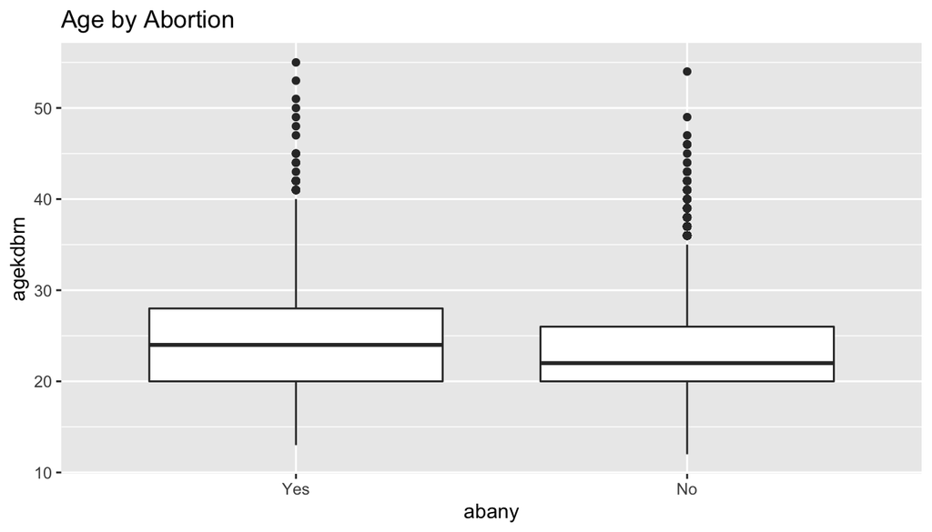

```r
abort_box <- ggplot(gss_trunc %>%
                      filter(!is.na(abany)),aes(abany,agekdbrn))+geom_boxplot()
abort_box + labs(title='Age by Abortion')
```

**Observation**: It appears that those who believe that women *should not* be able to obtain legal abortion tend to have had their first child at a **slightly younger** age than people who think otherwise. The former’s median is lower, and the IQR is slightly tighter.

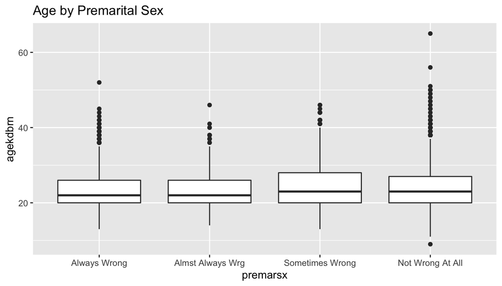

```r
premar_box <- ggplot(gss_trunc %>%
                      filter(!is.na(premarsx)),aes(premarsx,agekdbrn))+geom_boxplot()
premar_box + labs(title='Age by Premarital Sex')
```

**Observation**: It appears that the `Always Wrong` and `Almst Always Wrg` groups are very similar compared to the other two groups. The `Sometimes Wrong` group has a wider spread (larger IQR) than the others, and the `Not Wrong At All` group has larger outliers. These boxes look very similar to one another, and merely suggest to me that people who answered `Sometimes Wrong` tended to have their first child at a wider spread of ages than the others, given its IQR is larger than the others.

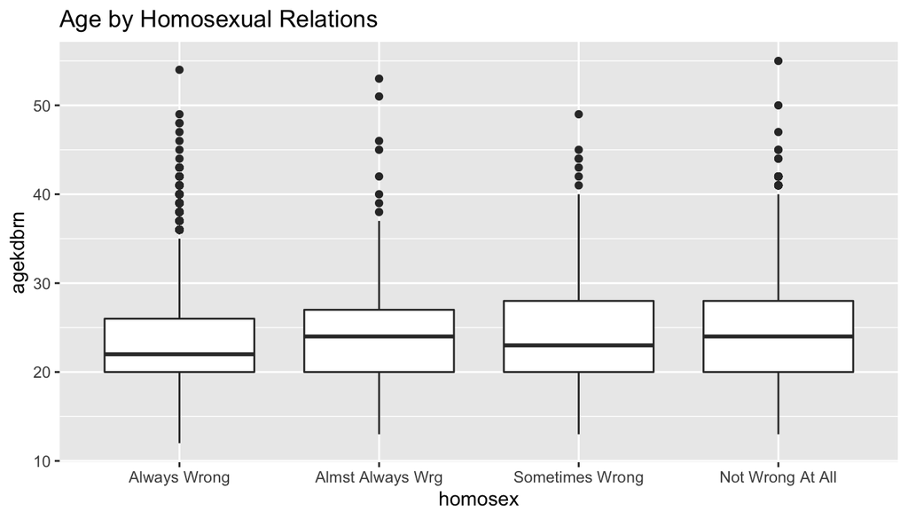

```r
homosx_box <- ggplot(gss_trunc %>%
                      filter(!is.na(homosex)),aes(homosex,agekdbrn))+geom_boxplot()
homosx_box + labs(title='Age by Homosexual Relations')
```

**Observation**: The `Always Wrong` group appears to have the lowest median and tightest spread per the IQR than the other three groups, suggesting that those who strongly believe that homosexual relations are always wrong tended to have their first child at an earlier age than those who responded differently.